# Module 2 Review

## Putting It All Together

- One-way ANOVA / Kruskal-Wallis:
  - Continuous outcome.
  - Only one factor (grouping variable).
    - More than two groups.
- Two-way ANOVA:
  - Continuous outcome.
  - Two factors (grouping variables), A & B.
    - More than two groups in each factor.
  - Interaction between factors A & B.
- ANOVA assumptions:
  - Normality of residuals.
  - Equal variances.

## Example 1

- Leif has started a veggie-gardening club in Animal Crossing. Four popular fertilizer options are being tried on carrot plots:
  1. Nook’s GreenGro
  2. Leif’s Compost Tea
  3. Brewster’s Grounds
  4. No fertilizer (control)
- Each option is applied to several 1 m<sup>2</sup> carrot plots (one fertilizer per plot). At harvest, villagers record the carrot yield (kg) from each plot.
- The research question is, *do mean carrot yields differ among the four fertilizer options*?

## Example 1

- Looking at summary statistics,

```
# A tibble: 4 × 4
  fertilizer         variable mean_sd   median_iqr
  <fct>              <chr>    <chr>     <chr>
1 No Fertilizer      yield_kg 1.5 (0.3) 1.5 (0.5)
2 Nook's GreenGro    yield_kg 1.8 (0.3) 1.7 (0.5)
3 Leif's Compost Tea yield_kg 2.1 (0.3) 2.2 (0.3)
4 Brewster's Grounds yield_kg 2.4 (0.3) 2.4 (0.3)
```

## Example 1

- Checking the ANOVA assumptions,

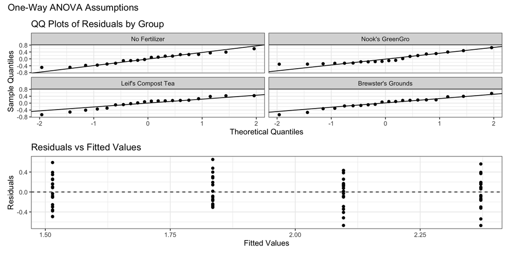

- Normality (qq plots) looks okay.
- Variance looks okay.

## Example 1

- Checking the ANOVA assumptions,

```
Brown-Forsythe-Levene test for equality of variances:
Null: σ²_Brewster's Grounds = σ²_Leif's Compost Tea = σ²_No Fertilizer = σ²_Nook's GreenGro
Alternative: At least one variance is different
Test statistic: F(3,76) = 0.093
p-value: p = 0.964
Conclusion: Fail to reject the null hypothesis (p = 0.964 ≥ α = 0.05)
```

- Is the variance assumption broken?

## Example 1

- Constructing the one-way ANOVA test,

```
One-Way ANOVA:
H₀: μ_No Fertilizer = μ_Nook's GreenGro = μ_Leif's Compost Tea = μ_Brewster's Grounds
H₁: At least one group mean is different
Test Statistic: F(3, 76) = 28.785
p-value: p < 0.001
Conclusion: Reject the null hypothesis (p = < 0.001 < α = 0.05)
```

- Is there a significant difference between the fertilizers?

## Example 1

- Suppose we want to look at posthoc tests to see which fertilizers differ.
- If we want to adjust, we will use Tukey’s,

| comparison | Mean Diff. | p-value |
| --- | --- | --- |
| Nook's GreenGro-No Fertilizer | 0.32 | 0.007 |
| Leif's Compost Tea-No Fertilizer | 0.58 | < 0.001 |
| Brewster's Grounds-No Fertilizer | 0.86 | < 0.001 |
| Leif's Compost Tea-Nook's GreenGro | 0.26 | 0.040 |
| Brewster's Grounds-Nook's GreenGro | 0.54 | < 0.001 |
| Brewster's Grounds-Leif's Compost Tea | 0.27 | 0.028 |

- Which fertilizers differ significantly?

## Example 1

| comparison | Mean Diff. | p-value |
| --- | --- | --- |
| No Fertilizer - Nook's GreenGro | -0.32 | 0.002 |
| No Fertilizer - Leif's Compost Tea | -0.58 | < 0.001 |
| No Fertilizer - Brewster's Grounds | -0.86 | < 0.001 |
| Nook's GreenGro - Leif's Compost Tea | -0.26 | 0.009 |
| Nook's GreenGro - Brewster's Grounds | -0.54 | < 0.001 |
| Leif's Compost Tea - Brewster's Grounds | -0.27 | 0.008 |

- Which fertilizers differ significantly?

## Example 2

- Leif notices some strange patterns this season. We now are testing our four fertilizer options on 1 m<sup>2</sup> tomato plots:
  1. Nook’s GreenGro
  2. Leif’s Compost Tea
  3. Brewster’s Grounds
  4. No fertilizer (control)
- Each option is applied to several 1 m<sup>2</sup> tomato plots (one fertilizer per plot). At harvest, villagers record the tomato yield (kg) from each plot.
- The research question is, *do mean tomato yields differ among the four fertilizer options*?

## Example 2

- Looking at summary statistics,

```
# A tibble: 4 × 4
  fertilizer         variable mean_sd   median_iqr
  <fct>              <chr>    <chr>     <chr>
1 No Fertilizer      yield_kg 1.7 (0.2) 1.6 (0.3)
2 Nook's GreenGro    yield_kg 1.9 (0.3) 2.0 (0.6)
3 Leif's Compost Tea yield_kg 2.3 (0.9) 1.8 (1.1)
4 Brewster's Grounds yield_kg 2.3 (0.5) 2.3 (0.5)
```

## Example 2

- Checking the ANOVA assumptions,

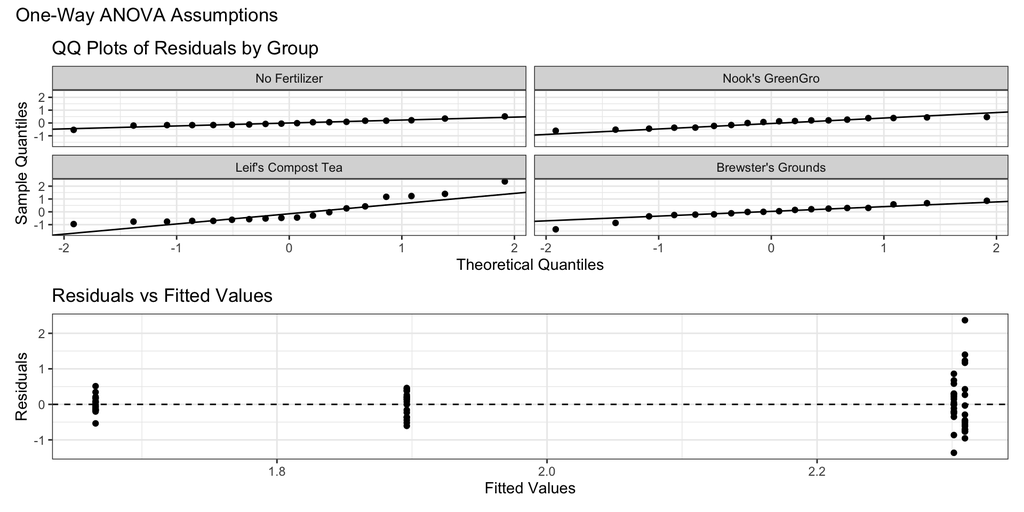

- Normality (qq plots) looks okay…?
- Variance is questionable…

## Example 2

- Checking the ANOVA assumptions,

```
Brown-Forsythe-Levene test for equality of variances:
Null: σ²_No Fertilizer = σ²_Nook's GreenGro = σ²_Leif's Compost Tea = σ²_Brewster's Grounds
Alternative: At least one variance is different
Test statistic: F(3,68) = 3.908
p-value: p = 0.012
Conclusion: Reject the null hypothesis (p = 0.012 < α = 0.05)
```

- Is the variance assumption broken?

## Example 2

- Constructing the Kruskal-Wallis test,

```
Kruskal–Wallis Rank-Sum Test

H₀: M_No Fertilizer = M_Nook's GreenGro = M_Leif's Compost Tea = M_Brewster's Grounds
H₁: At least one group is different

Test Statistic: X(3) = 16.959,
 p < 0.001
Conclusion: Reject the null hypothesis (p = < 0.001 < α = 0.05)
```

- Is there a significant difference between the fertilizers?

## Example 2

- Suppose we want to look at posthoc tests to see which fertilizers differ.
- If we want to adjust, we will use the adjusted version of Dunn’s test,

```
                               Comparison          Z     p
1 Brewster's Grounds - Leif's Compost Tea  1.4414191 0.897
2      Brewster's Grounds - No Fertilizer  4.0136753 0.000
3      Leif's Compost Tea - No Fertilizer  2.5722562 0.061
4    Brewster's Grounds - Nook's GreenGro  2.3492742 0.113
5    Leif's Compost Tea - Nook's GreenGro  0.9078551 1.000
6         No Fertilizer - Nook's GreenGro -1.6644010 0.576
```

- Which fertilizers differ significantly?

## Example 2

- Suppose we want to look at posthoc tests to see which fertilizers differ.
- If we do not want to adjust, we will use the unadjusted version of Dunn’s test,

```
                               Comparison          Z     p
1 Brewster's Grounds - Leif's Compost Tea  1.4414191 0.149
2      Brewster's Grounds - No Fertilizer  4.0136753 0.000
3      Leif's Compost Tea - No Fertilizer  2.5722562 0.010
4    Brewster's Grounds - Nook's GreenGro  2.3492742 0.019
5    Leif's Compost Tea - Nook's GreenGro  0.9078551 0.364
6         No Fertilizer - Nook's GreenGro -1.6644010 0.096
```

- Which fertilizers differ significantly?

## Example 3

- Leif is now testing the four fertilizer options on both carrot and tomato plots:
  1. Nook’s GreenGro
  2. Leif’s Compost Tea
  3. Brewster’s Grounds
  4. No fertilizer (control)
- The research questions are:
  1. *Is there an interaction between fertilizer type and crop type on yield?*
  2. *If no interaction, do mean crop yields differ among the four fertilizer options?*
  3. *If no interaction, do mean crop yields differ between carrot and tomato plots?*

## Example 3

- Looking at summary statistics,

```
# A tibble: 8 × 5
  crop   fertilizer         variable mean_sd   median_iqr
  <fct>  <fct>              <chr>    <chr>     <chr>
1 Carrot No Fertilizer      yield_kg 1.7 (0.3) 1.7 (0.3)
2 Carrot Nook's GreenGro    yield_kg 1.8 (0.3) 1.7 (0.3)
3 Carrot Leif's Compost Tea yield_kg 2.2 (0.4) 2.0 (0.6)
4 Carrot Brewster's Grounds yield_kg 2.4 (0.3) 2.5 (0.5)
5 Tomato No Fertilizer      yield_kg 1.7 (0.3) 1.7 (0.4)
6 Tomato Nook's GreenGro    yield_kg 1.9 (0.3) 2.0 (0.3)
7 Tomato Leif's Compost Tea yield_kg 2.4 (0.3) 2.3 (0.4)
8 Tomato Brewster's Grounds yield_kg 2.5 (0.4) 2.5 (0.5)
```

## Example 3

- Checking the two-way ANOVA assumptions,

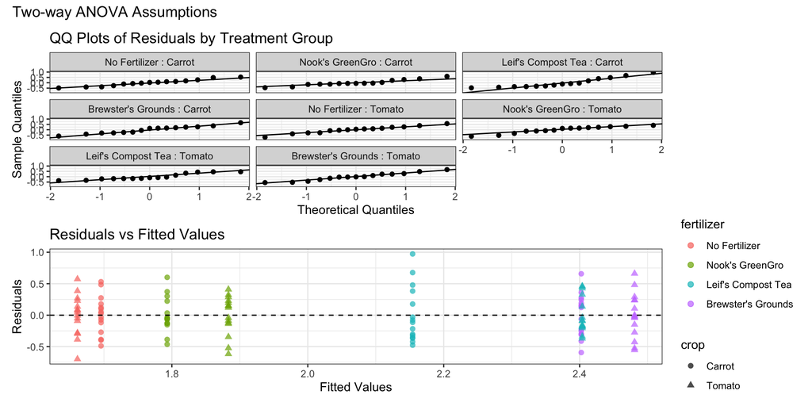

## Example 3

- Examining the two-way ANOVA (remember to always check for the interaction first!),

Two-Way ANOVA Table

| **Source** | **Sum of Squares** | *df* | **Mean Squares** | *F* | *p* |
| --- | --- | --- | --- | --- | --- |
| Regression | 12.24 | 7 |  |  |  |
| •fertilizer | 11.65 | 3 | 3.88 | 35.09 | < 0.001 |
| •crop | 0.28 | 1 | 0.28 | 2.49 | 0.117 |
| •Interaction | 0.31 | 3 | 0.10 | 0.93 | 0.431 |
| Error | 12.40 | 112 | 0.11 |  |  |
| Total | 24.63 | 119 |  |  |  |

- Is the interaction term significant?
- Should we keep or remove the interaction term?

## Example 3

- Removing the interaction term,

Two-Way ANOVA Table

| **Source** | **Sum of Squares** | *df* | **Mean Squares** | *F* | *p* |
| --- | --- | --- | --- | --- | --- |
| Regression | 11.93 | 4 |  |  |  |
| •fertilizer | 11.65 | 3 | 3.88 | 35.16 | < 0.001 |
| •crop | 0.28 | 1 | 0.28 | 2.50 | 0.117 |
| Error | 12.71 | 115 | 0.11 |  |  |
| Total | 24.63 | 119 |  |  |  |

- Are there signfiicant main effects?

## Example 3

- Looking at the tests for main effects,

```
Test for Main Effect fertilizer:

H₀: μ_No Fertilizer = μ_Nook's GreenGro = μ_Leif's Compost Tea = μ_Brewster's Grounds
H₁: At least one mean is different.
Test Statistic: F(3, 115) = 35.16
p-value: p = < 0.001
Conclusion: Reject the null hypothesis (p = < 0.001 < α = 0.05)

Test for Main Effect crop:

H₀: μ_Carrot = μ_Tomato
H₁: At least one mean is different.
Test Statistic: F(1, 115) = 2.5
p-value: p = 0.117
Conclusion: Fail to reject the null hypothesis (p = 0.117 ≥ α = 0.05)
```

- Is fertilizer a significant factor for crop yield?
- Is crop type a significant factor for crop yield?

## Example 3

- Looking at the profile plot,

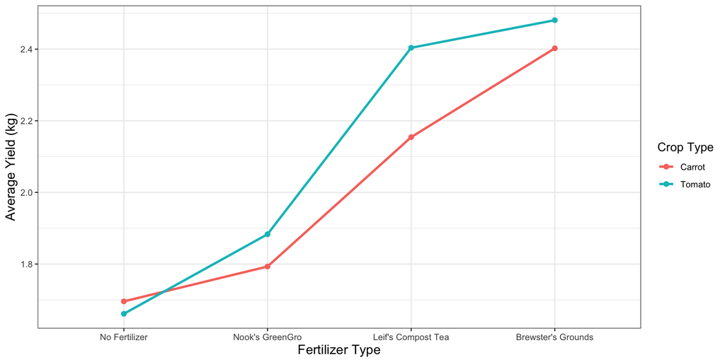

- What statements can we make about this analysis?

## Example 4

- Leif is now testing the four fertilizer options on both pumpkin, wheat, and potato plots:
  1. Nook’s GreenGro
  2. Leif’s Compost Tea
  3. Brewster’s Grounds
  4. No fertilizer (control)
- The research questions are:
  1. *Is there an interaction between fertilizer type and crop type on yield?*
  2. *If no interaction, do mean crop yields differ among the four fertilizer options?*
  3. *If no interaction, do mean crop yields differ among the three crop types?*

## Example 4

- Looking at summary statistics,

```
# A tibble: 12 × 5
   crop    fertilizer         variable mean_sd   median_iqr
   <fct>   <fct>              <chr>    <chr>     <chr>
 1 Pumpkin No Fertilizer      yield_kg 2.0 (0.2) 1.9 (0.2)
 2 Pumpkin Nook's GreenGro    yield_kg 2.3 (0.4) 2.1 (0.5)
 3 Pumpkin Leif's Compost Tea yield_kg 2.5 (0.4) 2.5 (0.6)
 4 Pumpkin Brewster's Grounds yield_kg 2.8 (0.3) 2.6 (0.3)
 5 Wheat   No Fertilizer      yield_kg 1.8 (0.2) 1.8 (0.3)
 6 Wheat   Nook's GreenGro    yield_kg 1.9 (0.2) 1.9 (0.1)
 7 Wheat   Leif's Compost Tea yield_kg 2.4 (0.3) 2.4 (0.3)
 8 Wheat   Brewster's Grounds yield_kg 2.3 (0.3) 2.3 (0.4)
 9 Potato  No Fertilizer      yield_kg 2.3 (0.3) 2.2 (0.3)
10 Potato  Nook's GreenGro    yield_kg 2.2 (0.3) 2.2 (0.5)
11 Potato  Leif's Compost Tea yield_kg 2.3 (0.3) 2.4 (0.3)
12 Potato  Brewster's Grounds yield_kg 2.4 (0.3) 2.4 (0.5)
```

## Example 4

- Checking the two-way ANOVA assumptions,

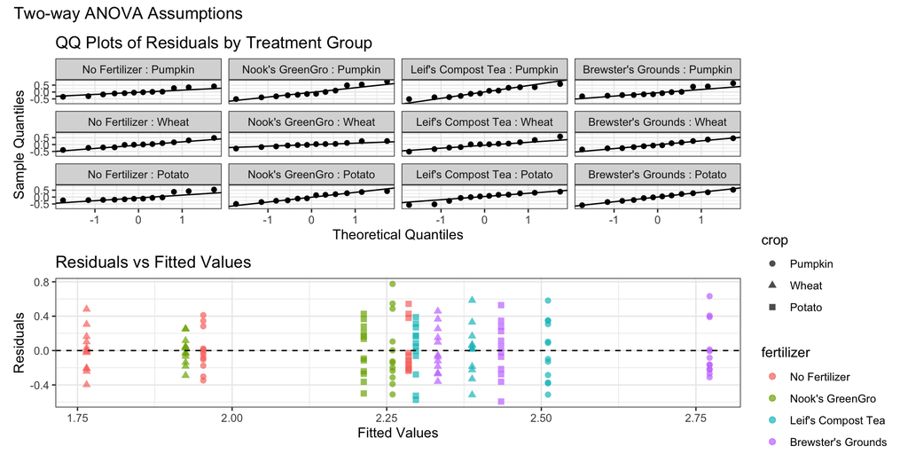

## Example 4

- Examining the two-way ANOVA (remember to always check for the interaction first!),

Two-Way ANOVA Table

| **Source** | **Sum of Squares** | *df* | **Mean Squares** | *F* | *p* |
| --- | --- | --- | --- | --- | --- |
| Regression | 10.00 | 11 |  |  |  |
| •fertilizer | 6.00 | 3 | 2.00 | 22.72 | < 0.001 |
| •crop | 1.92 | 2 | 0.96 | 10.92 | < 0.001 |
| •Interaction | 2.08 | 6 | 0.35 | 3.94 | 0.001 |
| Error | 11.62 | 132 | 0.09 |  |  |
| Total | 21.62 | 143 |  |  |  |

- Is the interaction term significant?
- Should we keep or remove the interaction term?

## Example 4

- Looking at the test for the interaction,

```
Test for Interaction (fertilizer × crop):

H₀: The relationship between yield_kg and fertilizer does not depend on crop.
H₁: The relationship between yield_kg and fertilizer depends on crop.
Test Statistic: F(6, 132) = 3.94
p-value: p = 0.001
Conclusion: Reject the null hypothesis (p = 0.001 < α = 0.05)
```

- Is there a significant interaction?

## Example 4

- Looking at the profile plot,

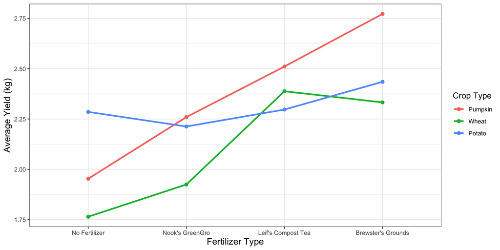

- What statements can we make about this analysis?

## Wrap Up

- Today’s review:
  - One-way ANOVA
  - Kruskal-Wallis
  - Posthoc testing
  - Two-way ANOVA
  - Interaction terms
  - Profile plots
  - ANOVA Assumptions
- Next class:
  - Regression!!!!! 💕